# STAT 184 Final Project: COVID-19 South Korea

Soung Mun Kim & Hogeun Choi

04/28/2020

# Idea & Goal

The main goal of this final project is to analyze how variabes such as sex and age are related to an infection rate of Covid-19 . Also, since Covid-19 is known as extremely contagious disease, we want to analyze whether it has a realtionship between an infection rate of Covid-19 and the population density or not in South Korea.

# How sex and age are related to an infection rate of Covid-19 and how population density related to an an infection rate of Covid-19 in South Korea?

```r
rm(list = ls())
devtools::install_github("cardiomoon/kormaps2014")
devtools::install_github("cardiomoon/moonBook2")
# These two packages take some time to install (Just for your information.)
install.packages("carData")
```

```
Error in install.packages : Updating loaded packages
```

```r
library(DataComputing)
library(dplyr)
library(tidyr)
library(readxl)
library(lubridate)
library(ggplot2)
library(kormaps2014)
library(moonBook2)
library(car)
```

## Preprocess the dataset

```r
Patient <- read.csv("PatientInfo.csv")
Region <- read.csv("Region.csv")
TotalCensus <- read_excel("Census 2015~2018.xlsx")
```

```
-
/
```

```r
Korpop <- read_excel("korpop.xlsx")
```

```
-
/
```

```r
# View datasets
head(Patient)
```

|  | patient_id | global_num | sex | birth_year | age | country | province | city | disease | infection_case | infection_order | infected_by | contact_number | symptom_onset_date | confirmed_date | released_date | deceased_date | state |
| --- | --- | --- | --- | --- | --- | --- | --- | --- | --- | --- | --- | --- | --- | --- | --- | --- | --- | --- |
| 1 | 1e+09 | 2 | male | 1964 | 50s | Korea | Seoul | Gangseo-gu | NA | overseas inflow | 1 | NA | 75 | 2020-01-22 | 2020-01-23 | 2020-02-05 |  | released |
| 2 | 1e+09 | 5 | male | 1987 | 30s | Korea | Seoul | Jungnang-gu | NA | overseas inflow | 1 | NA | 31 |  | 2020-01-30 | 2020-03-02 |  | released |
| 3 | 1e+09 | 6 | male | 1964 | 50s | Korea | Seoul | Jongno-gu | NA | contact with patient | 2 | 2.002e+09 | 17 |  | 2020-01-30 | 2020-02-19 |  | released |
| 4 | 1e+09 | 7 | male | 1991 | 20s | Korea | Seoul | Mapo-gu | NA | overseas inflow | 1 | NA | 9 | 2020-01-26 | 2020-01-30 | 2020-02-15 |  | released |
| 5 | 1e+09 | 9 | female | 1992 | 20s | Korea | Seoul | Seongbuk-gu | NA | contact with patient | 2 | 1.000e+09 | 2 |  | 2020-01-31 | 2020-02-24 |  | released |
| 6 | 1e+09 | 10 | female | 1966 | 50s | Korea | Seoul | Jongno-gu | NA | contact with patient | 3 | 1.000e+09 | 43 |  | 2020-01-31 | 2020-02-19 |  | released |

```r
head(Region)
```

|  | code | province | city | latitude | longitude | elementary_school_count | kindergarten_count | university_count | academy_ratio | elderly_population_ratio | elderly_alone_ratio | nursing_home_count |
| --- | --- | --- | --- | --- | --- | --- | --- | --- | --- | --- | --- | --- |
| 1 | 10000 | Seoul | Seoul | 37.56695 | 126.9780 | 607 | 830 | 48 | 1.44 | 15.38 | 5.8 | 22739 |
| 2 | 10010 | Seoul | Gangnam-gu | 37.51842 | 127.0472 | 33 | 38 | 0 | 4.18 | 13.17 | 4.3 | 3088 |
| 3 | 10020 | Seoul | Gangdong-gu | 37.53049 | 127.1238 | 27 | 32 | 0 | 1.54 | 14.55 | 5.4 | 1023 |
| 4 | 10030 | Seoul | Gangbuk-gu | 37.63994 | 127.0255 | 14 | 21 | 0 | 0.67 | 19.49 | 8.5 | 628 |
| 5 | 10040 | Seoul | Gangseo-gu | 37.55117 | 126.8495 | 36 | 56 | 1 | 1.17 | 14.39 | 5.7 | 1080 |
| 6 | 10050 | Seoul | Gwanak-gu | 37.47829 | 126.9515 | 22 | 33 | 1 | 0.89 | 15.12 | 4.9 | 909 |

```r
head(TotalCensus)
```

| Age | Total Population | Total Men | Total Women | Sex ratio | Total Local | Local Men | Local Women | Local sex ratio |
| --- | --- | --- | --- | --- | --- | --- | --- | --- |
| Total | 51629512 | 25877195 | 25752317 | 100.5 | 49977951 | 24931554 | 25046397 | 99.5 |
| 0~4 | 2000217 | 1025394 | 974823 | 105.2 | 1967942 | 1008953 | 958989 | 105.2 |
| 5~9 | 2279824 | 1172145 | 1107679 | 105.8 | 2261032 | 1162616 | 1098416 | 105.8 |
| 10~14 | 2262767 | 1169008 | 1093759 | 106.9 | 2250907 | 1163024 | 1087883 | 106.9 |
| 15~19 | 2772966 | 1445280 | 1327686 | 108.9 | 2735274 | 1427114 | 1308160 | 109.1 |
| 20~24 | 3484744 | 1851798 | 1632946 | 113.4 | 3290233 | 1744884 | 1545349 | 112.9 |

```r
head(Korpop)
```

| ...1 | Province Code | Province | Year | Total Population | Male | Female | Local | Male Local | Female Local | Foreigner | Male Foreigner | Female Foreigner | household | ordinary household | Collective household | foreigner household | house | detached house | apartment | townhouse | multiplex housing | House within commercial building | Living quarter other than housing unit | Code Province | Code |
| --- | --- | --- | --- | --- | --- | --- | --- | --- | --- | --- | --- | --- | --- | --- | --- | --- | --- | --- | --- | --- | --- | --- | --- | --- | --- |
| 5 | '11 | Seoul | 2015 | 9904312 | 4859535 | 5044777 | 9567196 | 4694317 | 4872879 | 337116 | 165218 | 171898 | 3914820 | 3784490 | 2261 | 128069 | 2793244 | 355039 | 1636896 | 117235 | 654372 | 29702 | 150951 | 11 | 11 |
| 455 | '21 | Busan | 2015 | 3448737 | 1701347 | 1747390 | 3404667 | 1675339 | 1729328 | 44070 | 26008 | 18062 | 1348315 | 1335900 | 686 | 11729 | 1164352 | 225697 | 738068 | 32120 | 154253 | 14214 | 50810 | 21 | 21 |
| 681 | '22 | Daegu | 2015 | 2466052 | 1228511 | 1237541 | 2436770 | 1211219 | 1225551 | 29282 | 17292 | 11990 | 937573 | 928528 | 574 | 8471 | 738100 | 155801 | 509068 | 9381 | 53098 | 10752 | 15304 | 22 | 22 |
| 832 | '23 | Incheon | 2015 | 2890451 | 1455017 | 1435434 | 2822601 | 1414793 | 1407808 | 67850 | 40224 | 27626 | 1066297 | 1045417 | 713 | 20167 | 942244 | 102914 | 577346 | 21589 | 232346 | 8049 | 39964 | 23 | 23 |
| 995 | '24 | Gwangju | 2015 | 1502881 | 748867 | 754014 | 1481289 | 736656 | 744633 | 21592 | 12211 | 9381 | 573181 | 567157 | 438 | 5586 | 486527 | 88401 | 376731 | 7396 | 8517 | 5482 | 10625 | 24 | 24 |
| 1096 | '25 | Daejeon | 2015 | 1538394 | 772243 | 766151 | 1519314 | 763310 | 756004 | 19080 | 8933 | 10147 | 588395 | 582504 | 420 | 5471 | 468885 | 81292 | 338250 | 10068 | 34151 | 5124 | 10676 | 25 | 25 |

```r
#Checking NA in the dataset
colSums(is.na(Patient))
```

```
        patient_id         global_num                sex         birth_year                age            country           province               city            disease
                 0               1171                  0                420                  0                  0                  0                  0               3235
    infection_case    infection_order        infected_by     contact_number symptom_onset_date     confirmed_date      released_date      deceased_date              state
                 0               3222               2490               2656                  0                  0                  0                  0                  0
```

```r
colSums(is.na(Region))
```

```
                    code                 province                     city                 latitude                longitude  elementary_school_count
                       0                        0                        0                        0                        0                        0
      kindergarten_count         university_count            academy_ratio elderly_population_ratio      elderly_alone_ratio       nursing_home_count
                       0                        0                        0                        0                        0                        0
```

```r
colSums(is.na(TotalCensus))
```

```
             Age Total Population        Total Men      Total Women        Sex ratio      Total Local        Local Men      Local Women  Local sex ratio
               0                0                0                0                0                0                0                0                0
```

```r
colSums(is.na(Korpop))
```

```
                                  ...1                          Province Code                               Province                                   Year
                                     0                                      0                                      0                                      0
                      Total Population                                   Male                                 Female                                  Local
                                     0                                      0                                      0                                      0
                            Male Local                           Female Local                              Foreigner                         Male Foreigner
                                     0                                      0                                      0                                      0
                      Female Foreigner                              household                     ordinary household                   Collective household
                                     0                                      0                                      0                                      0
                   foreigner household                                  house                         detached house                              apartment
                                     0                                      0                                      0                                      0
                             townhouse                      multiplex housing       House within commercial building Living quarter other than housing unit
                                     0                                      0                                      0                                      0
                         Code Province                                   Code
                                     0                                      0
```

```r
#Filling missing values in the Patient dataset
Fill_na <- function(df) {
  na_cols <- names(which(colSums(is.na(df)) != 0))
  for (i in na_cols)
    df[, i][is.na(df[, i])] <- mean(df[, i], na.rm = T)
  return(df)
}
Patient <- Fill_na(Patient)
colSums(is.na(Patient))
```

```
        patient_id         global_num                sex         birth_year                age            country           province               city            disease
                 0                  0                  0                  0                  0                  0                  0                  0                  0
    infection_case    infection_order        infected_by     contact_number symptom_onset_date     confirmed_date      released_date      deceased_date              state
                 0                  0                  0                  0                  0                  0                  0                  0                  0
```

## EDA (exploratory data analysis)

```r
#glimpse(Patient)
#Making space to NA in sex and age variables
Patient$sex[Patient$sex == ""] <- "NA"
```

```
invalid factor level, NA generated
```

```r
Patient$age[Patient$age == ""] <- "NA"
```

```
invalid factor level, NA generated
```

```r
Patient$age[Patient$age == "100s"] <- "90s"
Patient$age[Patient$age == "66s"] <- "60s"
Patient# arrange dataset by adding ratio variales
```

[output not shown]

[output cut: 990 more lines]

```r
TOTAL <- as.numeric(TotalCensus[1,2])
TotalCensus <-
TotalCensus%>%
  select(Age, `Total Population`,`Total Men`,`Total Women`)%>%
  mutate(total_ratio = `Total Population`/TOTAL)%>%
  mutate(Men_ratio = `Total Men` / `Total Population`)%>%
  mutate(Women_ratio = `Total Women` / `Total Population`)%>%
  subset( ,c(1,2,5,3,6,4,7))
# women ratio and men ratio
p <- c(TotalCensus[1,5],TotalCensus[1,7])
names(p) <-c("Male","Female")
p <- as.numeric(p)
x <-Patient%>%
group_by(sex)%>%
summarise(Total = n())%>%
filter(sex!='NA')%>%
arrange(desc(sex))
```

```
Factor `sex` contains implicit NA, consider using `forcats::fct_explicit_na`
```

```r
# women and men in the population in Korea
x$null <- p
xtest <- x$Total
x
```

| sex | Total | null |
| --- | --- | --- |
| male | 1402 | 0.5012094 |
| female | 1798 | 0.4987906 |

## How sex is related with infection rate of COVID-19 in South Korea?

There are confirmed COVID 19 patients: 1402 males and 1798 females in South Korea. Also, in this table, null column shows the ratio of male and female based on total census in South Korea.

```r
# using chi-square test for checking that it has the difference between ratio of men and women in COVID19 confirmed people and ratio of men and women in the population in Korea
chisq.test(xtest,p=p)
```

```
    Chi-squared test for given probabilities

data:  xtest
X-squared = 50.94, df = 1, p-value = 9.525e-13
```

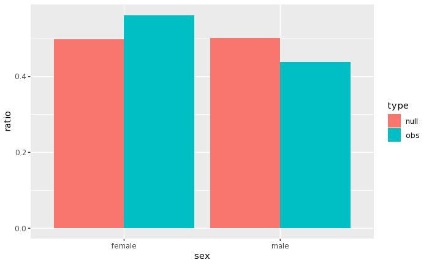

```r
#graph
x$obs <- x$Total/sum(x$Total)
x%>%
  gather(type,prob,null,obs)%>%
  ggplot(aes(x=sex, y=prob, fill=type))+
  geom_bar(stat='identity',position = 'dodge') +
  ylab("ratio")
```

On the graph, “null” bar shows the population ratio of sex and the “obs” bar shows the confirmed case ratio of sex. By looking at the data, we can say there is a valid difference between “null” and “obs”. The female group contains more confirmed cases than male group. Also if you see the Chi-square Goodness of fit test result, we can see the p-value is almost equal to zero, which means that the distribution of two group is different from the theoretical one (population distribution). Through this graph, we can assume that women are more likely to be infected with the COVID 19 than men in South Korea.

## How age is related with infection rate of COVID-19 in South Korea?

```r
#null probll
Ages <- c("Total","0s","0s","10s","10s","20s","20s","30s","30s","40s","40s","50s","50s","60s","60s","70s","70s","80s","80s","90s","90s","90s")
Census_by_Age <-
  TotalCensus%>%
  select(Age,`Total Population`)%>%
  filter(Age!="85 Over",Age!="15 Less",Age!="15~64",Age!="65 Over",Age!="Average Age",Age!="Median Age")%>%
  cbind(Ages)%>%
  group_by(Ages)%>%
  summarise("Total" = sum(`Total Population`))
Census_by_Age
```

| Ages | Total |
| --- | --- |
| 0s | 4280041 |
| 10s | 5035733 |
| 20s | 7004966 |
| 30s | 7446677 |
| 40s | 8408883 |
| 50s | 8515725 |
| 60s | 5854493 |
| 70s | 3415142 |
| 80s | 1473354 |
| 90s | 194498 |

[output cut: 1 more lines]

```r
null_prob <- (Census_by_Age$Total/TOTAL)[1:10]
```

This table shows total population which is grouped by their age. There are larger populations from 20s to 50s ages than other age groups.

```r
#Observed prob
Observed<- Patient%>%
  group_by(age)%>%
  summarise(total=n())%>%
  filter(age!=" ")%>%
  arrange(age)
```

```
Factor `age` contains implicit NA, consider using `forcats::fct_explicit_na`
```

```r
Observed
```

| age | total |
| --- | --- |
| 0s | 47 |
| 10s | 136 |
| 20s | 779 |
| 30s | 418 |
| 40s | 445 |
| 50s | 582 |
| 60s | 390 |
| 70s | 195 |
| 80s | 154 |
| 90s | 46 |

This table shows total of confirmed patients which is grouped by their age. There are more COVID 19 confirmed patients in 20s and 50s ages than in other age groups. In particular, there are more patients in their 20s than those of other ages in confirmed cases.

```r
null_prob
```

```
 [1] 0.082899118 0.097535940 0.135677556 0.144232953 0.162869697 0.164939095 0.113394312 0.066147090 0.028537051 0.003767186
```

```r
Observed$null <- as.vector(null_prob)
#chi square test
realob<-Observed$total
chisq.test(realob,p=null_prob)
```

```
    Chi-squared test for given probabilities

data:  realob
X-squared = 717.39, df = 9, p-value < 2.2e-16
```

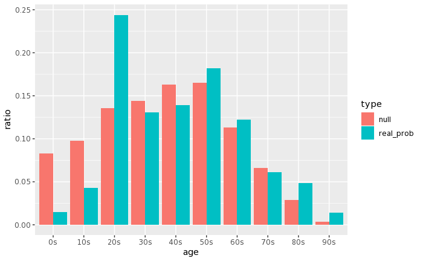

```r
#graph
graph <-Observed%>%
  mutate(real_prob=(Observed$total/sum(Observed$total)))%>%
  gather("type","prob",null,real_prob)
graph%>%
ggplot(aes(x=age, y=prob, fill=type))+
  geom_bar(stat = 'identity',position='dodge')+
  ylab("ratio")
```

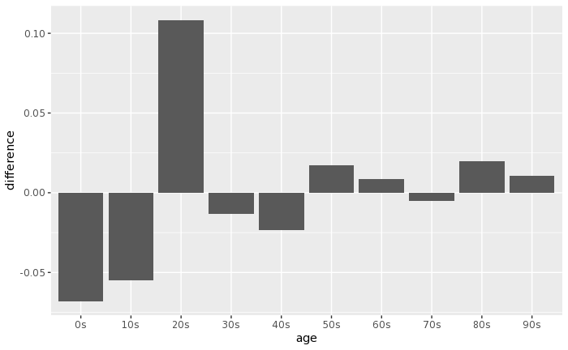

```r
#contribution
Observed%>%
  mutate(real_prob=(Observed$total/sum(Observed$total)))%>%
  mutate(difference=real_prob-null)%>%
  select(age,difference)%>%
  ggplot(aes(x=age, y=difference))+
  geom_bar(stat = 'identity')
```

As you can see the grah, 20s cotnributes the most to the Chi-square test. 0s and 10s gropus contribute in second and third. Since COVID-19 is very contagious, we can assume that the activity of the age groups may affect to the incidence rate of the age groups.

## How population density and provinces’ traits are related with infection rate of COVID-19 in South Korea

### SouthKorea map based on population distribution by Province

[figure not shown]

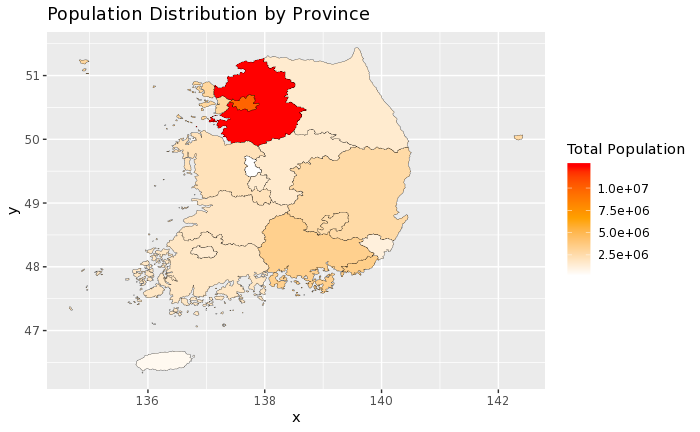

```r
ggplot(Korpop,aes(map_id=Code,fill=`Total Population`))+
  geom_map(map=kormap1,colour='black',size=0.1)+
  expand_limits(x=kormap1$long,y=kormap1$lat)+
  scale_fill_gradientn(colours=c('white','orange','red'))+
  ggtitle("Population Distribution by Province")
```

```r
# ratio of confirmed patients grouped by province
Patitnet_total <-
  Patient%>%
  count()%>%
  as.numeric()
Patient%>%
  group_by(province)%>%
  summarise(total = n())%>%
  mutate(ratio = total/ Patitnet_total) %>%
  arrange(desc(ratio))
```

| province | total | ratio |
| --- | --- | --- |
| Gyeongsangbuk-do | 1204 | 0.370119889 |
| Gyeonggi-do | 634 | 0.194897018 |
| Seoul | 610 | 0.187519213 |
| Chungcheongnam-do | 139 | 0.042729788 |
| Busan | 123 | 0.037811251 |
| Gyeongsangnam-do | 114 | 0.035044574 |
| Incheon | 87 | 0.026744543 |
| Daegu | 63 | 0.019366738 |
| Sejong | 46 | 0.014140793 |
| Chungcheongbuk-do | 44 | 0.013525976 |

[output cut: 7 more lines]

In February, more than three hundreds of confirmed cases suddenly occurred in Gyeongsangbuk-do when a woman in Gyeongsangbuk-do was infected with COVID 19 and went to a religious assembly attened by more than one thousand people. Therefore, this table shows Gyongsangbuk-do has the highest confirmed cases. However, except in this certain cases, the areas (Provinces) with the largest total population have a high level of COVID infection like Gyeonggi-do and Seoul.

### Regression model

```r
#group by province factor in Patient data.
Patientprovince <- Patient%>%
  group_by(province)%>%
  summarise(total_patient = n())
#arrange the province name in Region and change to the vector.
prov_name <- Region%>%
  group_by(province)%>%
  summarise(total = n())
prov_name <- as.vector(prov_name$province)
#filter the needed province data.
Region_prov <- Region%>%
  filter(city %in% prov_name)
Region_prov <- Region_prov%>%
  select(city,elementary_school_count,kindergarten_count,university_count,academy_ratio,elderly_population_ratio)
#combine two data by using left join.
Regression_table <-Patientprovince%>%
  left_join(Region_prov, by = c("province"="city"))
```

```r
Regression_table <- Korpop%>%
  group_by(Province)%>%
  summarise(`Total Population`)%>%
  right_join(Regression_table, by = c("Province"="province"))
Regression_table
```

| Province | Total Population | total_patient | elementary_school_count | kindergarten_count | university_count | academy_ratio | elderly_population_ratio |
| --- | --- | --- | --- | --- | --- | --- | --- |
| Busan | 3448737 | 123 | 304 | 408 | 22 | 1.40 | 18.41 |
| Chungcheongbuk-do | 1589347 | 44 | 259 | 328 | 17 | 1.39 | 17.28 |
| Chungcheongnam-do | 2107802 | 139 | 409 | 499 | 21 | 1.38 | 18.40 |
| Daegu | 2466052 | 63 | 229 | 355 | 11 | 1.62 | 15.78 |
| Daejeon | 1538394 | 39 | 148 | 260 | 15 | 1.49 | 13.65 |
| Gangwon-do | 1518040 | 37 | 349 | 368 | 18 | 1.42 | 19.89 |
| Gwangju | 1502881 | 27 | 155 | 312 | 17 | 2.38 | 13.57 |
| Gyeonggi-do | 12479061 | 634 | 1277 | 2237 | 61 | 1.60 | 12.63 |
| Gyeongsangbuk-do | 2680294 | 1204 | 471 | 707 | 33 | 1.33 | 20.85 |
| Gyeongsangnam-do | 3334524 | 114 | 501 | 686 | 21 | 1.78 | 16.51 |

[output cut: 7 more lines]

We organized and added the data. The data above includes Total poulation and totla patient and other features of the regions such as the number of the universities and elderly population ratio.

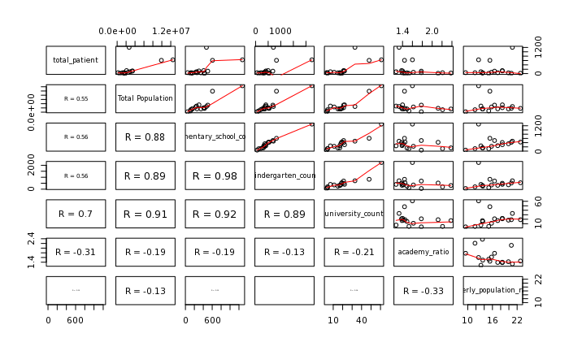

```r
#factor analysis
panel.cor <- function(x, y){
    usr <- par("usr"); on.exit(par(usr))
    par(usr = c(0, 1, 0, 1))
    r <- round(cor(x, y), digits=2)
    txt <- paste0("R = ", r)
    cex.cor <- 0.8/strwidth(txt)
    text(0.5, 0.5, txt, cex = cex.cor * r)
}
#correlation matrix
pairs(~total_patient+`Total Population`+elementary_school_count+kindergarten_count+university_count+academy_ratio+elderly_population_ratio,data = Regression_table,panel = panel.smooth, lower.panel = panel.cor)
```

The above graph shows the correlation between the factors. Some of the correlations are high and some of them are not. We can see that the number of university and confirmed case in a region is correlated by 0.7, which might be significant. Therefore, we can check this by using regression modelling.

```r
#regression modeling
Regression_model <- lm(total_patient ~
`Total Population`+elementary_school_count+kindergarten_count+university_count+academy_ratio+elderly_population_ratio ,data=Regression_table)
#test with the regression model
Regression_model;summary(Regression_model)
```

```
Call:
lm(formula = total_patient ~ `Total Population` + elementary_school_count +
    kindergarten_count + university_count + academy_ratio + elderly_population_ratio,
    data = Regression_table)

Coefficients:
             (Intercept)        `Total Population`   elementary_school_count        kindergarten_count          university_count             academy_ratio
               4.035e+02                -7.053e-05                -1.652e+00                 7.692e-01                 3.367e+01                -2.439e+02
elderly_population_ratio
              -5.332e+00


Call:
lm(formula = total_patient ~ `Total Population` + elementary_school_count +
    kindergarten_count + university_count + academy_ratio + elderly_population_ratio,
    data = Regression_table)

Residuals:
    Min      1Q  Median      3Q     Max
-280.43 -134.48   22.83   73.73  547.97

Coefficients:
                           Estimate Std. Error t value Pr(>|t|)
(Intercept)               4.035e+02  6.839e+02   0.590   0.5683
`Total Population`       -7.053e-05  7.568e-05  -0.932   0.3733
elementary_school_count  -1.652e+00  2.023e+00  -0.816   0.4333
kindergarten_count        7.692e-01  1.063e+00   0.724   0.4857
university_count          3.367e+01  1.466e+01   2.297   0.0445 *
academy_ratio            -2.439e+02  2.139e+02  -1.141   0.2806
elderly_population_ratio -5.332e+00  3.760e+01  -0.142   0.8901
---
Signif. codes:  0 ‘***’ 0.001 ‘**’ 0.01 ‘*’ 0.05 ‘.’ 0.1 ‘ ’ 1

Residual standard error: 249.6 on 10 degrees of freedom
Multiple R-squared:  0.627, Adjusted R-squared:  0.4033
F-statistic: 2.802 on 6 and 10 DF,  p-value: 0.0724
```

Since only the pvalue of the university_count predictor is less than 0.05, we can say the only university_count predictor is significant predictor at 5% level. However, this model is not significant becasuse F test of P value does not less than 0.05. Therefore, we have to drop some predictor which is not significant and fit signficant model for looking up which predictor is significant.

```r
#Choose what to remove by using VIF.
vif(Regression_model)
```

```
      `Total Population`  elementary_school_count       kindergarten_count         university_count            academy_ratio elderly_population_ratio
               15.380800                84.810494                68.931668                12.905194                 1.262117                 4.797380
```

We remove three top “VIF” variables, which are “elementary school count”,“kindergarten count” and “Total Population”.

```r
#remove elemenatary school, kindergarten factor, and Total population
Regression_model <- lm(total_patient ~
university_count+academy_ratio+elderly_population_ratio ,data=Regression_table)
Regression_model;summary(Regression_model); vif(Regression_model)
```

```
Call:
lm(formula = total_patient ~ university_count + academy_ratio +
    elderly_population_ratio, data = Regression_table)

Coefficients:
             (Intercept)          university_count             academy_ratio  elderly_population_ratio
                188.9257                   14.0812                 -163.9735                   -0.8075


Call:
lm(formula = total_patient ~ university_count + academy_ratio +
    elderly_population_ratio, data = Regression_table)

Residuals:
    Min      1Q  Median      3Q     Max
-185.29 -131.28  -65.43   18.41  785.32

Coefficients:
                          Estimate Std. Error t value Pr(>|t|)
(Intercept)               188.9257   521.2397   0.362  0.72284
university_count           14.0812     4.1935   3.358  0.00514 **
academy_ratio            -163.9735   204.2394  -0.803  0.43649
elderly_population_ratio   -0.8075    18.2263  -0.044  0.96534
---
Signif. codes:  0 ‘***’ 0.001 ‘**’ 0.01 ‘*’ 0.05 ‘.’ 0.1 ‘ ’ 1

Residual standard error: 249.3 on 13 degrees of freedom
Multiple R-squared:  0.5163,    Adjusted R-squared:  0.4047
F-statistic: 4.626 on 3 and 13 DF,  p-value: 0.0206

        university_count            academy_ratio elderly_population_ratio
                1.058367                 1.153840                 1.129919
```

As you can see. the p-value becomes lower from 0.0724 to 0.0206. Also the VIF of all three variables are less than 5. This model is more developed one than before. Although, we think it would be better to remove other variables with p-value over 0.05. Therefore, we removed “academy_ratio” and “elderly_population_ratio”.

```r
#remove academy ratio and elderly population ratio.
Regression_model <- lm(total_patient ~
university_count ,data=Regression_table)
Regression_model;summary(Regression_model)
```

```
Call:
lm(formula = total_patient ~ university_count, data = Regression_table)

Coefficients:
     (Intercept)  university_count
          -104.7              14.8


Call:
lm(formula = total_patient ~ university_count, data = Regression_table)

Residuals:
    Min      1Q  Median      3Q     Max
-164.32 -119.94  -78.33   57.51  820.19

Coefficients:
                 Estimate Std. Error t value Pr(>|t|)
(Intercept)      -104.727     96.958  -1.080  0.29715
university_count   14.804      3.894   3.802  0.00174 **
---
Signif. codes:  0 ‘***’ 0.001 ‘**’ 0.01 ‘*’ 0.05 ‘.’ 0.1 ‘ ’ 1

Residual standard error: 238.1 on 15 degrees of freedom
Multiple R-squared:  0.4907,    Adjusted R-squared:  0.4568
F-statistic: 14.45 on 1 and 15 DF,  p-value: 0.001737
```

The result says as the province has 1 more university, 14.804 more people are infected in the province.Also the model says infected people will be -104.727 if there is no university in the province.

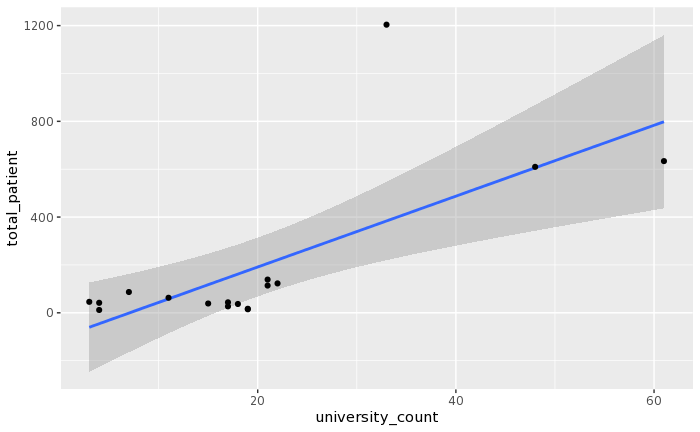

```r
#graph of the regression model
Regression_table%>%
ggplot(aes(x=university_count, y=total_patient))+
geom_smooth(method = lm)+
geom_point()
```

This model contains only university variable. This has lesser p-value for both F-test and T-test. We can say this is valid model with more accuracy. The intercept interpretation does not make sense, but we can still see the correlation between two variables.

### Now, compare the population and the university variable.

```r
Regression_model <- lm(total_patient ~
`Total Population`,data=Regression_table)
Regression_model;summary(Regression_model)
```

```
Call:
lm(formula = total_patient ~ `Total Population`, data = Regression_table)

Coefficients:
       (Intercept)  `Total Population`
         2.504e+01           5.536e-05


Call:
lm(formula = total_patient ~ `Total Population`, data = Regression_table)

Residuals:
    Min      1Q  Median      3Q     Max
-109.64  -95.65  -72.08  -46.56 1030.57

Coefficients:
                    Estimate Std. Error t value Pr(>|t|)
(Intercept)        2.504e+01  9.328e+01   0.268    0.792
`Total Population` 5.536e-05  2.148e-05   2.578    0.021 *
---
Signif. codes:  0 ‘***’ 0.001 ‘**’ 0.01 ‘*’ 0.05 ‘.’ 0.1 ‘ ’ 1

Residual standard error: 277.8 on 15 degrees of freedom
Multiple R-squared:  0.307, Adjusted R-squared:  0.2608
F-statistic: 6.646 on 1 and 15 DF,  p-value: 0.021
```

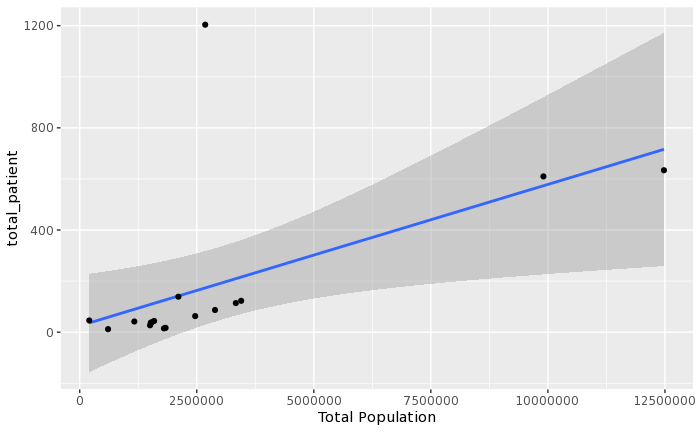

```r
#graph of the regression model
Regression_table%>%
ggplot(aes(x=`Total Population`, y=total_patient))+
geom_smooth(method = lm)+
geom_point()
```

## Conclusion

First, sex is related to an infection rate of COVID-19 in South Korea. The female ratio of confirmed case has larger than 5% difference compare to the female ratio of population. A p-value of Goodness of fit test support the assertion. The P-value is almost zero. This means there are clear different between two. We cannot say that female is more vulnerable to the COVID-19 variable, but there is clear different between the # of confirmed male and that of female in South Korea. The sex variable is valid explanatory variable with more than 95% confident.